# GM12878: three assemblies annotated with PyTransDecoder

This notebook supports two manuscript sections:

- Methods, GM12878 transcriptome assemblies (`../manuscript/sections/methods_gm12878_assemblies.tex`);
- Results, annotating three GM12878 transcriptome assemblies, with Table `tab:gm12878` (`../manuscript/sections/results_gm12878_application.tex`);

and draws Fig. 6 (`fig:gm12878`, `figures/fig6_gm12878.{pdf,png}`). Panels c-e of Fig. 6 (Ribo-seq and MS) are drawn here; the numbers the text quotes from them are computed in `07_gm12878_evidence.Rmd`.

Provenance: E11 (reads, STAR, Trinity), E03 (assemblies, PyTD runs, evaluation metrics), E05 (expressed-gene sensitivity), E25 (release reruns).

Figures and the numbers written in this notebook use the **release** runs. The earlier values are shown next to them, and the checks at the end compare the release values with the text, so a mismatch shows a number the text must update.

Data (all in `data/`):

- `benchmark/final_v7/eval.<asm>_final_v7_abinitio.summary.tsv`: release evaluation summaries (`eval_genome_cds.py`; identical to `$P/work/gm12878_td/eval/`).
- `gm12878/eval_summaries/<asm>_final_abinitio.summary.tsv`: earlier evaluation summaries (E03).
- `gm12878/final_v7/06_*.tsv`, written by `pipeline/derive/06_gm12878_application.sh` (calls `06_gm12878_tables.py`) from the per-reference and per-prediction status tables, the genome-map logs and the genome GFF3 files of both runs:
  - `06_gm12878_inputs.tsv`: read and transcript counts of the inputs;
  - `06_gm12878_genome_map.tsv`: transcript ORFs and those projected to the genome;
  - `06_gm12878_class_by_length.tsv`: distinct predicted CDSs by protein length and GENCODE class;
  - `06_gm12878_mane_not_exact.tsv`: assembled MANE CDSs not predicted exactly, and whether a prediction has the same stop codon;
  - `06_gm12878_v7_expressed_sensitivity.tsv`: `expressed_sensitivity.py` (E05 method) on the release runs.
- `gm12878/gm12878_expressed_sensitivity.tsv`: the same for the earlier runs (E05).
- `benchmark/final_v7/gm12878_v7_riboseq_support.tsv`, `gm12878_v7_ms_peptide_support.tsv` (E25) and `gm12878/final_v7/gm12878_v7_riboseq_stringtie_by_expression.tsv` (`pipeline/derive/07_gm12878_evidence_v7.sh`): Fig. 6c-e.

```r
ASMS <- c("lraa", "stringtie", "trinity")
SHORT <- c(lraa = "LRAA", stringtie = "StringTie", trinity = "Trinity")
read_summary <- function(run, asm) {
  f <- if (run == "release") data_path("benchmark", "final_v7", sprintf("eval.%s_final_v7_abinitio.summary.tsv", asm))
       else data_path("gm12878", "eval_summaries", sprintf("%s_final_abinitio.summary.tsv", asm))
  read_tsv(f, col_names = c("metric", "value"), col_types = "cc") %>%
    filter(metric != "label") %>% mutate(value = as.numeric(value), run = run, assembly = asm)
}
summ <- bind_rows(lapply(c("release", "earlier"), function(r) bind_rows(lapply(ASMS, read_summary, run = r))))
# S("release", "lraa", "MANE_exact"); vectorised over assemblies when asm = ASMS
S <- function(run, asm, metric) {
  v <- sapply(asm, function(a) summ$value[summ$run == run & summ$assembly == a & summ$metric == metric])
  setNames(as.numeric(v), asm)
}
R <- function(metric, asm = ASMS) S("release", asm, metric)
E <- function(metric, asm = ASMS) S("earlier", asm, metric)

by_len <- read_tab("gm12878", "final_v7", "06_gm12878_class_by_length.tsv")
# The summaries round fractions to 4 decimals; a value ending in 5 then rounds ambiguously at 3 decimals.
# Recompute the fractions that have counts: exact given assembled = exact / assembled (every exact
# reference is also assembled, E03), and the prediction-class fractions from the class counts.
cnt <- by_len %>% group_by(run, assembly) %>%
  summarise(n = sum(n), ex = sum(exact), co = sum(exact) + sum(compatible), nov = sum(novel), .groups = "drop")
recomp <- bind_rows(
  summ %>% filter(metric %in% c("MANE_exact", "MANE_assembled", "GENCODE_complete_exact", "GENCODE_complete_assembled")) %>%
    pivot_wider(names_from = metric, values_from = value) %>%
    transmute(run, assembly, MANE_sens_exact_given_assembled = MANE_exact / MANE_assembled,
              GENCODE_complete_sens_exact_given_assembled = GENCODE_complete_exact / GENCODE_complete_assembled) %>%
    pivot_longer(-c(run, assembly), names_to = "metric"),
  cnt %>% transmute(run, assembly, pred_all_GENCODE_exact_frac = ex / n, pred_all_GENCODE_compatible_frac = co / n,
                    pred_all_no_GENCODE_CDS_overlap_frac = nov / n) %>%
    pivot_longer(-c(run, assembly), names_to = "metric"))
chk <- recomp %>% inner_join(summ, by = c("run", "assembly", "metric"))
stopifnot(all(abs(chk$value.x - chk$value.y) < 6e-5))
summ <- summ %>% anti_join(recomp, by = c("run", "assembly", "metric")) %>% bind_rows(recomp)

inputs <- read_tab("gm12878", "final_v7", "06_gm12878_inputs.tsv")
I <- function(m) inputs$value[inputs$metric == m]
gmap <- read_tab("gm12878", "final_v7", "06_gm12878_genome_map.tsv")
not_exact <- read_tab("gm12878", "final_v7", "06_gm12878_mane_not_exact.tsv")
expr_rel <- read_tab("gm12878", "final_v7", "06_gm12878_v7_expressed_sensitivity.tsv") %>% mutate(run = "release")
expr_ear <- read_tab("gm12878", "gm12878_expressed_sensitivity.tsv") %>% mutate(run = "earlier")
expr <- bind_rows(expr_rel, expr_ear)
ribo <- read_tab("benchmark", "final_v7", "gm12878_v7_riboseq_support.tsv") %>% filter(assembly %in% ASMS)
ms <- read_tab("benchmark", "final_v7", "gm12878_v7_ms_peptide_support.tsv") %>% filter(assembly %in% ASMS)
ribo_expr <- read_tab("gm12878", "final_v7", "gm12878_v7_riboseq_stringtie_by_expression.tsv")
```

## GM12878 transcriptome assemblies (Methods)

Inputs (`06_gm12878_inputs.tsv`, from the STAR, minimap2 and read-count logs; E11, E03):

- Short reads: 97,548,052 pairs (97.5 million), 83.31% uniquely mapped by STAR.
- StringTie: 83,342 transcripts.
- Trinity GG: 428,960 transcripts, 428,223 with a primary minimap2 alignment.
- Long reads: 2,538,701 FLNC reads (2.5 million); LRAA: 39,530 transcripts.
- References: 19,229 MANE Select transcripts on the primary assembly and 253,709 GENCODE v50 protein-coding transcripts with complete CDSs.

The assembled-transcript counts used by the evaluation equal these counts: 39,530 / 83,342 / 428,223 (LRAA / StringTie / Trinity).

The Methods text names PyTD commit 48c870c. That is the commit of the earlier runs; the release runs used PyTD main 3a793ff (E25).

```r
stopifnot(R("assembled_transcripts")[["lraa"]] == I("lraa_transcripts"),
          R("assembled_transcripts")[["stringtie"]] == I("stringtie_transcripts"),
          R("assembled_transcripts")[["trinity"]] == I("trinity_primary_mapped"))
kable(inputs)
```

| metric | value | source |
| --- | --- | --- |
| short_read_pairs | 97548052.00 | STAR Log.final.out |
| short_read_unique_pct | 83.31 | STAR Log.final.out |
| long_reads_flnc | 2538701.00 | logs/readcount_long.txt |
| stringtie_transcripts | 83342.00 | stringtie.gtf |
| lraa_transcripts | 39530.00 | LRAA.gtf |
| trinity_transcripts | 428960.00 | Trinity.fasta |
| trinity_primary_mapped | 428223.00 | Trinity.minimap2.flagstat |

## Annotating three GM12878 transcriptome assemblies

The three assemblies differ in size: 428,223 aligned Trinity transcripts, against 83,342 (StringTie) and 39,530 (LRAA). The long-read sample had 2.5 million reads. E03

## Predictions

```r
n_rel <- R("distinct_predicted_cds"); n_ear <- E("distinct_predicted_cds")
part_rel <- n_rel - R("distinct_predicted_complete"); part_ear <- n_ear - E("distinct_predicted_complete")
gm <- gmap %>% mutate(not_projected = transcript_orfs - projected, frac_not = not_projected / transcript_orfs)
g <- function(run, asm, col) gm[[col]][gm$run == run & gm$assembly == asm]
kable(gm, digits = 3)
```

| run | assembly | transcript_orfs | projected | skipped_unaligned_cds | skipped_no_structure | not_projected | frac_not |
| --- | --- | --- | --- | --- | --- | --- | --- |
| earlier | lraa | 34592 | 34592 | 0 | 0 | 0 | 0.000 |
| earlier | stringtie | 40666 | 40666 | 0 | 0 | 0 | 0.000 |
| earlier | trinity | 97088 | 92464 | 4611 | 13 | 4624 | 0.048 |
| release | lraa | 33028 | 33028 | 0 | 0 | 0 | 0.000 |
| release | stringtie | 36479 | 36479 | 0 | 0 | 0 | 0.000 |
| release | trinity | 80797 | 77481 | 3312 | 4 | 3316 | 0.041 |

Release runs: PyTD predicted 22,769 (LRAA), 30,846 (StringTie) and 59,514 (Trinity) distinct CDSs after genome projection (earlier runs: 23,922 / 34,404 / 72,323). Partial CDSs made up 22% / 22% / 25% of the predictions (earlier: 21% / 21% / 28%).

All LRAA and StringTie ORFs were projected to the genome. Trinity lost 3,316 of 80,797 ORFs (4.1%): 3,312 with a CDS outside the aligned part of the transcript and 4 on unmapped transcripts. In the earlier run it lost 4,624 of 97,088 (4.8%). E03, E25

## CDS prediction on assembled transcripts

```r
ega_mane <- R("MANE_sens_exact_given_assembled"); ega_gc <- R("GENCODE_complete_sens_exact_given_assembled")
ne <- not_exact %>% mutate(frac_same_stop = same_stop / assembled_not_exact,
                           frac_upstream = same_stop_start_upstream / same_stop)
ss <- function(run, asm) ne$frac_same_stop[ne$run == run & ne$assembly == asm]
kable(ne, digits = 3)
```

| run | assembly | assembled | exact_and_assembled | assembled_not_exact | same_stop | same_stop_start_upstream | same_stop_start_downstream | frac_same_stop | frac_upstream |
| --- | --- | --- | --- | --- | --- | --- | --- | --- | --- |
| earlier | lraa | 6294 | 5882 | 412 | 263 | 242 | 21 | 0.638 | 0.920 |
| earlier | stringtie | 8919 | 8268 | 651 | 454 | 412 | 42 | 0.697 | 0.907 |
| earlier | trinity | 7676 | 6951 | 725 | 496 | 362 | 134 | 0.684 | 0.730 |
| release | lraa | 6294 | 5848 | 446 | 258 | 239 | 19 | 0.578 | 0.926 |
| release | stringtie | 8919 | 8160 | 759 | 457 | 415 | 42 | 0.602 | 0.908 |
| release | trinity | 7676 | 6857 | 819 | 495 | 364 | 131 | 0.604 | 0.735 |

Exact given assembled (release) was 0.893–0.929 for MANE Select (earlier 0.906–0.935) and 0.856–0.882 for complete GENCODE CDSs (earlier 0.876–0.889).

Assembled MANE CDSs that were not predicted exactly: for 58% (LRAA), 60% (StringTie) and 60% (Trinity), a predicted CDS (complete or 5′ partial) had the same stop codon, so it differed only at the start. In most of these the predicted start was upstream of the MANE start (93% / 91% / 74%). With the earlier runs the same count gives 64% (LRAA) and 70% (StringTie).

The text quotes the release values (58% LRAA, 60% StringTie and Trinity) and states this definition in the Methods: any distinct predicted CDS on the same chromosome and strand with the same stop codon. An earlier draft quoted 62% and 68% from the earlier runs, by a definition no record documents; the definition used here gives 64% and 70% on those runs.

## Table: PyTD on three GM12878 assemblies

```r
rows <- tribble(
  ~row,                                         ~metric,
  "Distinct predicted CDSs",                    "distinct_predicted_cds",
  "complete",                                   "distinct_predicted_complete",
  "partial",                                    "partial",
  "MANE assembled",                             "MANE_assembled_frac",
  "MANE exact",                                 "MANE_sens_exact",
  "MANE compatible",                            "MANE_sens_compatible",
  "MANE exact given assembled",                 "MANE_sens_exact_given_assembled",
  "GENCODE complete exact",                     "GENCODE_complete_sens_exact",
  "GENCODE complete compatible",                "GENCODE_complete_sens_compatible",
  "GENCODE exact given assembled",              "GENCODE_complete_sens_exact_given_assembled",
  "Predictions identical to a GENCODE CDS",     "pred_all_GENCODE_exact_frac",
  "Predictions compatible with a GENCODE CDS",  "pred_all_GENCODE_compatible_frac",
  "Predictions with no GENCODE CDS overlap",    "pred_all_no_GENCODE_CDS_overlap_frac"
)
summ_p <- summ %>% bind_rows(
  summ %>% filter(metric %in% c("distinct_predicted_cds", "distinct_predicted_complete")) %>%
    pivot_wider(names_from = metric, values_from = value) %>%
    transmute(run, assembly, metric = "partial", value = distinct_predicted_cds - distinct_predicted_complete))
tab <- rows %>% left_join(summ_p, by = "metric", relationship = "many-to-many") %>%
  mutate(value = ifelse(value >= 1, num(value), f3(round(value, 3)))) %>%
  mutate(col = paste(SHORT[assembly], run)) %>% select(row, col, value) %>%
  pivot_wider(names_from = col, values_from = value) %>%
  select(row, `LRAA release`, `StringTie release`, `Trinity release`,
         `LRAA earlier`, `StringTie earlier`, `Trinity earlier`)
kable(tab, align = "lrrrrrr")
```

| row | LRAA release | StringTie release | Trinity release | LRAA earlier | StringTie earlier | Trinity earlier |
| --- | --- | --- | --- | --- | --- | --- |
| Distinct predicted CDSs | 22,769 | 30,846 | 59,514 | 23,922 | 34,404 | 72,323 |
| complete | 17,806 | 24,077 | 44,494 | 18,807 | 27,034 | 52,123 |
| partial | 4,963 | 6,769 | 15,020 | 5,115 | 7,370 | 20,200 |
| MANE assembled | 0.327 | 0.464 | 0.399 | 0.327 | 0.464 | 0.399 |
| MANE exact | 0.304 | 0.424 | 0.357 | 0.306 | 0.430 | 0.362 |
| MANE compatible | 0.392 | 0.563 | 0.534 | 0.395 | 0.569 | 0.547 |
| MANE exact given assembled | 0.929 | 0.915 | 0.893 | 0.935 | 0.927 | 0.906 |
| GENCODE complete exact | 0.191 | 0.229 | 0.204 | 0.192 | 0.234 | 0.209 |
| GENCODE complete compatible | 0.265 | 0.344 | 0.427 | 0.269 | 0.352 | 0.446 |
| GENCODE exact given assembled | 0.882 | 0.868 | 0.856 | 0.889 | 0.886 | 0.876 |
| Predictions identical to a GENCODE CDS | 0.520 | 0.434 | 0.225 | 0.503 | 0.401 | 0.191 |
| Predictions compatible with a GENCODE CDS | 0.747 | 0.667 | 0.488 | 0.726 | 0.616 | 0.423 |
| Predictions with no GENCODE CDS overlap | 0.015 | 0.055 | 0.042 | 0.037 | 0.120 | 0.155 |

## Sensitivity is limited by assembly

```r
mane_e <- expr %>% filter(set == "MANE")
X <- function(run_, asm, tpm, col) mane_e[[col]][mane_e$run == run_ & mane_e$label == asm & mane_e$tpm_min == tpm]
n_tpm1 <- unique(mane_e$n[mane_e$tpm_min == 1]); n_tpm10 <- unique(mane_e$n[mane_e$tpm_min == 10])
st_ex1 <- X("release", "stringtie", 1, "sens_exact"); st_ex10 <- X("release", "stringtie", 10, "sens_exact")
comp1 <- sapply(c("stringtie", "trinity"), X, run_ = "release", tpm = 1, col = "sens_compatible")
comp10 <- sapply(c("stringtie", "trinity"), X, run_ = "release", tpm = 10, col = "sens_compatible")
ega_expr <- mane_e %>% filter(run == "release", tpm_min > 0) %>% pull(sens_exact_given_assembled)
lraa_ex <- c(X("release", "lraa", 1, "sens_exact"), X("release", "lraa", 10, "sens_exact"))
stopifnot(all(abs(sapply(ASMS, X, run_ = "release", tpm = 0, col = "sens_exact") - R("MANE_sens_exact")) < 1e-4))
expr %>% filter(set == "MANE") %>% arrange(run, label, tpm_min) %>% kable(digits = 3)
```

| label | set | tpm_min | n | assembled_frac | sens_exact | sens_compatible | sens_exact_given_assembled | run |
| --- | --- | --- | --- | --- | --- | --- | --- | --- |
| lraa | MANE | 0 | 19229 | 0.327 | 0.306 | 0.395 | 0.934 | earlier |
| lraa | MANE | 1 | 11076 | 0.544 | 0.510 | 0.655 | 0.936 | earlier |
| lraa | MANE | 5 | 9360 | 0.592 | 0.555 | 0.710 | 0.937 | earlier |
| lraa | MANE | 10 | 7823 | 0.621 | 0.580 | 0.731 | 0.935 | earlier |
| stringtie | MANE | 0 | 19229 | 0.464 | 0.430 | 0.569 | 0.927 | earlier |
| stringtie | MANE | 1 | 11076 | 0.796 | 0.741 | 0.879 | 0.931 | earlier |
| stringtie | MANE | 5 | 9360 | 0.857 | 0.799 | 0.896 | 0.932 | earlier |
| stringtie | MANE | 10 | 7823 | 0.874 | 0.814 | 0.898 | 0.931 | earlier |
| trinity | MANE | 0 | 19229 | 0.399 | 0.362 | 0.547 | 0.905 | earlier |
| trinity | MANE | 1 | 11076 | 0.688 | 0.625 | 0.892 | 0.909 | earlier |
| trinity | MANE | 5 | 9360 | 0.760 | 0.692 | 0.909 | 0.910 | earlier |
| trinity | MANE | 10 | 7823 | 0.777 | 0.707 | 0.913 | 0.909 | earlier |
| lraa | MANE | 0 | 19229 | 0.327 | 0.304 | 0.392 | 0.929 | release |
| lraa | MANE | 1 | 11076 | 0.544 | 0.507 | 0.649 | 0.931 | release |
| lraa | MANE | 5 | 9360 | 0.592 | 0.552 | 0.704 | 0.932 | release |
| lraa | MANE | 10 | 7823 | 0.621 | 0.578 | 0.726 | 0.931 | release |
| stringtie | MANE | 0 | 19229 | 0.464 | 0.424 | 0.563 | 0.915 | release |
| stringtie | MANE | 1 | 11076 | 0.796 | 0.731 | 0.867 | 0.919 | release |
| stringtie | MANE | 5 | 9360 | 0.857 | 0.788 | 0.884 | 0.920 | release |
| stringtie | MANE | 10 | 7823 | 0.874 | 0.803 | 0.886 | 0.919 | release |
| trinity | MANE | 0 | 19229 | 0.399 | 0.357 | 0.534 | 0.893 | release |
| trinity | MANE | 1 | 11076 | 0.688 | 0.617 | 0.874 | 0.896 | release |
| trinity | MANE | 5 | 9360 | 0.760 | 0.683 | 0.893 | 0.898 | release |
| trinity | MANE | 10 | 7823 | 0.777 | 0.697 | 0.898 | 0.897 | release |

Release runs, all MANE Select CDSs: 30%–42% predicted exactly and 39%–56% compatibly; assembled 33%–46% (the assembled fractions do not depend on the PyTD run).

MANE genes expressed at gene TPM ≥ 1: 11,076 genes. StringTie plus PyTD gave the exact MANE CDS for 73% (earlier 74%); StringTie and Trinity gave a compatible CDS for 87%–87%. At TPM ≥ 10 (7,823 genes): StringTie exact 80%, compatible 89%–90% (StringTie, Trinity). Exact given assembled at TPM ≥ 1, 5 and 10: 0.896–0.932. LRAA exact at TPM ≥ 1 and ≥ 10: 0.507 and 0.578. E05, E25

## Assembly type

GENCODE complete compatible sensitivity (release): 0.265 / 0.344 / 0.427 (LRAA / StringTie / Trinity). Share of predictions identical to a GENCODE CDS: 52% / 43% / 22%; compatible with a GENCODE CDS: 75% / 67% / 49%. Among complete predictions, identical to a GENCODE CDS: 66% / 56% / 30% (earlier 64% / 51% / 27%). E03, E25

## Unannotated predictions

```r
un <- tibble(assembly = ASMS,
             all_release = R("pred_all_no_GENCODE_CDS_overlap_frac"),
             partial_release = R("pred_partial_no_GENCODE_CDS_overlap_frac"),
             complete_release = R("pred_complete_no_GENCODE_CDS_overlap_frac"),
             all_earlier = E("pred_all_no_GENCODE_CDS_overlap_frac"),
             partial_earlier = E("pred_partial_no_GENCODE_CDS_overlap_frac"),
             complete_earlier = E("pred_complete_no_GENCODE_CDS_overlap_frac"))
n_novel <- by_len %>% group_by(run, assembly) %>% summarise(novel = sum(novel), n = sum(n), .groups = "drop")
kable(un, digits = 4)
```

| assembly | all_release | partial_release | complete_release | all_earlier | partial_earlier | complete_earlier |
| --- | --- | --- | --- | --- | --- | --- |
| lraa | 0.0150 | 0.0171 | 0.0144 | 0.0370 | 0.0299 | 0.0389 |
| stringtie | 0.0547 | 0.1143 | 0.0379 | 0.1200 | 0.1813 | 0.1032 |
| trinity | 0.0425 | 0.0769 | 0.0309 | 0.1553 | 0.2412 | 0.1221 |

Release runs: predictions with no same-strand overlap with any GENCODE CDS made up 1.5% (LRAA), 5.5% (StringTie) and 4.2% (Trinity) of distinct CDSs (341 / 1,687 / 2,528 CDSs; earlier 3.7% / 12.0% / 15.5%). Among partial predictions of the short-read assemblies: 11% (StringTie), 8% (Trinity); among complete ones: 4%, 3%. The release test removes most of them: the counts fall from 885 / 4,127 / 11,235 to 341 / 1,687 / 2,528. E03, E25

## Figure 6

Same panels as the earlier matplotlib figure (`figures/fig6_gm12878/make_fig6.py`), drawn from the release runs. Panel b of the earlier figure was made by `figures/fig6_gm12878/derive_class_by_length.py`; the `earlier` rows of `06_gm12878_class_by_length.tsv` equal its output (`figures/fig6_gm12878/data/pred_class_by_length.tsv`, checked below).

```r
CLASSES <- c("exact", "compatible", "other_overlap", "novel")
CLASS_LAB <- c(exact = "GENCODE exact", compatible = "compatible", other_overlap = "other overlap",
               novel = "unannotated")
CLASS_COLOR <- c(exact = "#08519c", compatible = "#6baed6", other_overlap = "#bdbdbd", novel = "#e7298a")
asm_f <- function(x) factor(x, levels = ASMS, labels = SHORT[ASMS])
cls_f <- function(x) factor(x, levels = CLASSES, labels = CLASS_LAB[CLASSES])
ASM_COL <- setNames(ASM_COLOR[ASMS], SHORT[ASMS])

old_len <- read_tab("..", "figures", "fig6_gm12878", "data", "pred_class_by_length.tsv")
stopifnot(isTRUE(all.equal(as.data.frame(by_len %>% filter(run == "earlier") %>% select(-run)),
                           as.data.frame(old_len), check.attributes = FALSE)))

# a: MANE Select recovery by expression threshold
pa_d <- expr_rel %>% filter(set == "MANE", tpm_min %in% c(0, 1, 10)) %>%
  mutate(assembly = asm_f(label), tpm = factor(tpm_min, levels = c(0, 1, 10), labels = c("all", "≥1", "≥10")))
# b: class composition by length
BINS <- c("lt100", "100-149", "150-199", "200-299", "ge300")
BIN_LAB <- c("<100", "100–149", "150–199", "200–299", "≥300")
pb_d <- by_len %>% filter(run == "release") %>%
  pivot_longer(all_of(CLASSES), names_to = "class", values_to = "count") %>%
  mutate(frac = count / n, assembly = asm_f(assembly), class = cls_f(class),
         length_bin = factor(length_bin, levels = BINS, labels = BIN_LAB))
stopifnot(all(by_len %>% filter(run == "release") %>% group_by(assembly) %>% summarise(n = sum(n)) %>%
                pull(n) == R("distinct_predicted_cds")))
# c: Ribo-seq
pc_d <- ribo %>% filter(class %in% CLASSES) %>%
  mutate(frac_psites = with_min_psites / n, frac_frame0 = supported / n,
         assembly = asm_f(assembly), class = cls_f(class))
# d: MS
pd_d <- ms %>% filter(size %in% c("long", "short")) %>%
  select(assembly, class, size, n, frac_ge1) %>%
  pivot_wider(names_from = size, values_from = c(n, frac_ge1)) %>%
  mutate(assembly = asm_f(assembly), class = cls_f(class))
# e: Ribo-seq by expression (StringTie)
TPMB <- c("a<1", "b1-5", "c5-20", "d20-100", "e>=100")
pe_d <- ribo_expr %>% mutate(class = cls_f(class), tpm_bin = factor(tpm_bin, levels = TPMB,
                                                                     labels = c("<1", "1–5", "5–20", "20–100", "≥100")))
```

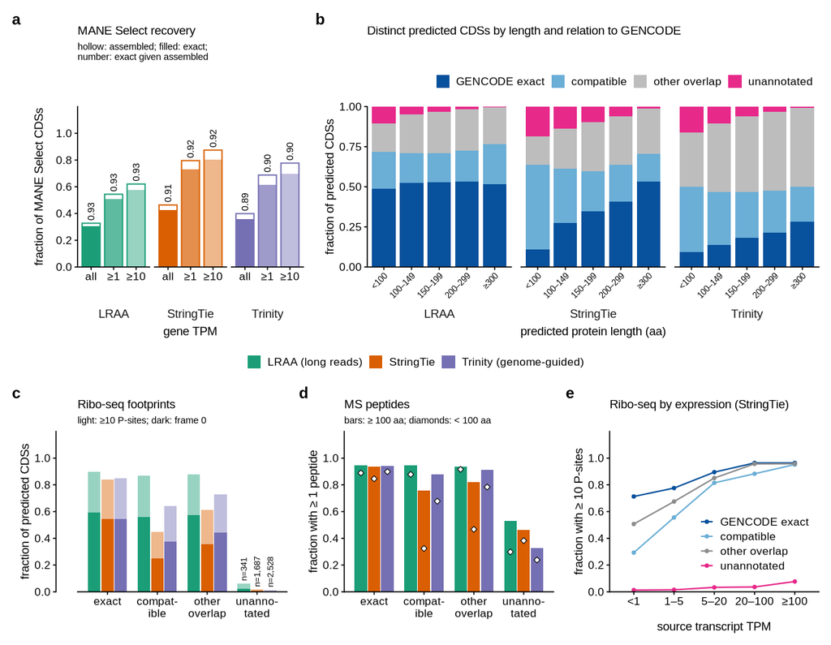

```r
pa <- ggplot(pa_d, aes(tpm)) +
  geom_col(aes(y = assembled_frac, colour = assembly), fill = "white", width = 0.8, linewidth = 0.35) +
  geom_col(aes(y = sens_exact, fill = assembly, alpha = tpm), width = 0.8) +
  geom_text(aes(y = assembled_frac + 0.02, label = sprintf("%.2f", sens_exact_given_assembled)),
            angle = 90, hjust = 0, size = 5.5 / .pt) +
  facet_wrap(~assembly, nrow = 1, strip.position = "bottom") +
  scale_fill_manual(values = ASM_COL, guide = "none") + scale_colour_manual(values = ASM_COL, guide = "none") +
  scale_alpha_manual(values = c(1, 0.7, 0.45), guide = "none") +
  scale_y_continuous(limits = c(0, 1.2), breaks = seq(0, 1, 0.2), expand = c(0, 0)) +
  labs(x = "gene TPM", y = "fraction of MANE Select CDSs", title = "MANE Select recovery",
       subtitle = "hollow: assembled; filled: exact;\nnumber: exact given assembled") +
  theme(strip.placement = "outside", panel.spacing = unit(1, "mm"),
        plot.subtitle = element_text(size = 5.5))

pb <- ggplot(pb_d, aes(length_bin, frac, fill = class)) +
  geom_col(width = 0.85, position = position_stack(reverse = TRUE)) +
  facet_wrap(~assembly, nrow = 1, strip.position = "bottom") +
  scale_fill_manual(values = setNames(CLASS_COLOR, CLASS_LAB[CLASSES]), name = NULL) +
  scale_y_continuous(expand = c(0, 0)) +
  labs(x = "predicted protein length (aa)", y = "fraction of predicted CDSs",
       title = "Distinct predicted CDSs by length and relation to GENCODE") +
  theme(strip.placement = "outside", legend.position = "top", legend.justification = "right",
        axis.text.x = element_text(angle = 45, hjust = 1, size = 5), panel.spacing = unit(2, "mm"))

dodge <- position_dodge(width = 0.8)
SHORT_CLS <- c("GENCODE exact" = "exact", compatible = "compat-\nible", "other overlap" = "other\noverlap",
               unannotated = "unanno-\ntated")
pc <- ggplot(pc_d, aes(class, group = assembly)) +
  geom_col(aes(y = frac_psites, fill = assembly), alpha = 0.45, width = 0.75, position = dodge) +
  geom_col(aes(y = frac_frame0, fill = assembly), width = 0.75, position = dodge) +
  geom_text(data = pc_d %>% filter(class == "unannotated"),
            aes(y = frac_psites + 0.02, label = paste0("n=", num(n))), position = dodge,
            angle = 90, hjust = 0, size = 5 / .pt) +
  scale_fill_manual(values = ASM_COL, name = NULL) +
  scale_y_continuous(limits = c(0, 1.2), breaks = seq(0, 1, 0.2), expand = c(0, 0)) +
  scale_x_discrete(labels = SHORT_CLS) +
  labs(x = NULL, y = "fraction of predicted CDSs", title = "Ribo-seq footprints",
       subtitle = "light: ≥10 P-sites; dark: frame 0") +
  theme(legend.position = "none", plot.subtitle = element_text(size = 5.5))

pd <- ggplot(pd_d, aes(class, group = assembly)) +
  geom_col(aes(y = frac_ge1_long, fill = assembly), width = 0.75, position = dodge) +
  geom_point(aes(y = frac_ge1_short), position = dodge, shape = 23, size = 1.1, fill = "white",
             colour = "black", stroke = 0.3) +
  scale_fill_manual(values = ASM_COL, name = NULL) +
  scale_y_continuous(limits = c(0, 1.2), breaks = seq(0, 1, 0.2), expand = c(0, 0)) +
  scale_x_discrete(labels = SHORT_CLS) +
  labs(x = NULL, y = "fraction with ≥ 1 peptide", title = "MS peptides",
       subtitle = "bars: ≥ 100 aa; diamonds: < 100 aa") +
  theme(legend.position = "none", plot.subtitle = element_text(size = 5.5))

pe <- ggplot(pe_d, aes(tpm_bin, frac_ge10_psites, colour = class, group = class)) +
  geom_line(linewidth = 0.4) + geom_point(size = 0.8) +
  scale_colour_manual(values = setNames(replace(CLASS_COLOR, "other_overlap", "#8c8c8c"), CLASS_LAB[CLASSES]),
                      name = NULL) +
  scale_y_continuous(limits = c(0, 1.2), breaks = seq(0, 1, 0.2), expand = c(0, 0)) +
  labs(x = "source transcript TPM", y = "fraction with ≥ 10 P-sites", title = "Ribo-seq by expression (StringTie)") +
  theme(legend.position = "inside", legend.position.inside = c(0.98, 0.3), legend.justification = c(1, 0.5))

# assembly legend: shared by panels a, c, d
asm_legend <- ggplot(tibble(assembly = factor(ASM_LABEL[ASMS], levels = ASM_LABEL[ASMS]), x = 1, y = 1),
                     aes(x, y, fill = assembly)) + geom_col() +
  scale_fill_manual(values = setNames(ASM_COLOR[ASMS], ASM_LABEL[ASMS]), name = NULL) +
  theme(legend.position = "top", legend.direction = "horizontal")
leg_g <- ggplotGrob(asm_legend)
leg <- wrap_elements(full = leg_g$grobs[[which(leg_g$layout$name == "guide-box-top")]])

fig6 <- (pa + pb + plot_layout(widths = c(2, 4))) / leg / (pc + pd + pe) +
  plot_layout(heights = c(1, 0.06, 1)) +
  plot_annotation(tag_levels = list(c("a", "b", "", "c", "d", "e")))
save_fig(fig6, "fig6_gm12878", FULL_W, 5.2)
fig6
```

### Plotted values

**MANE Select recovery (release; gene TPM thresholds)**

```r
pa_d %>% select(assembly, tpm_min, n, assembled_frac, sens_exact, sens_exact_given_assembled) %>% kable(digits = 4)
```

| assembly | tpm_min | n | assembled_frac | sens_exact | sens_exact_given_assembled |
| --- | --- | --- | --- | --- | --- |
| LRAA | 0 | 19229 | 0.3273 | 0.3041 | 0.9291 |
| LRAA | 1 | 11076 | 0.5443 | 0.5070 | 0.9313 |
| LRAA | 10 | 7823 | 0.6206 | 0.5775 | 0.9306 |
| StringTie | 0 | 19229 | 0.4638 | 0.4244 | 0.9149 |
| StringTie | 1 | 11076 | 0.7957 | 0.7313 | 0.9191 |
| StringTie | 10 | 7823 | 0.8742 | 0.8030 | 0.9186 |
| Trinity | 0 | 19229 | 0.3992 | 0.3566 | 0.8933 |
| Trinity | 1 | 11076 | 0.6881 | 0.6167 | 0.8963 |
| Trinity | 10 | 7823 | 0.7771 | 0.6969 | 0.8969 |

**Class composition by predicted protein length (release; counts)**

```r
by_len %>% filter(run == "release") %>% select(-run) %>% kable()
```

| assembly | length_bin | n | exact | compatible | other_overlap | novel |
| --- | --- | --- | --- | --- | --- | --- |
| lraa | lt100 | 536 | 261 | 123 | 95 | 57 |
| lraa | 100-149 | 1627 | 852 | 304 | 390 | 81 |
| lraa | 150-199 | 2217 | 1169 | 406 | 570 | 72 |
| lraa | 200-299 | 4330 | 2300 | 849 | 1104 | 77 |
| lraa | ge300 | 14059 | 7249 | 3506 | 3250 | 54 |
| stringtie | lt100 | 2272 | 246 | 1204 | 396 | 426 |
| stringtie | 100-149 | 3082 | 840 | 1049 | 771 | 422 |
| stringtie | 150-199 | 3298 | 1142 | 827 | 1011 | 318 |
| stringtie | 200-299 | 5438 | 2221 | 1243 | 1652 | 322 |
| stringtie | ge300 | 16756 | 8948 | 2842 | 4767 | 199 |
| trinity | lt100 | 4061 | 383 | 1645 | 1382 | 651 |
| trinity | 100-149 | 7648 | 1051 | 2519 | 3268 | 810 |
| trinity | 150-199 | 7498 | 1349 | 2156 | 3526 | 467 |
| trinity | 200-299 | 11435 | 2430 | 3006 | 5606 | 393 |
| trinity | ge300 | 28872 | 8173 | 6317 | 14175 | 207 |

**Ribo-seq: ≥ 10 P-sites and frame-0 test, by class (release)**

```r
pc_d %>% select(assembly, class, n, with_min_psites, supported, frac_psites, frac_frame0) %>% kable(digits = 4)
```

| assembly | class | n | with_min_psites | supported | frac_psites | frac_frame0 |
| --- | --- | --- | --- | --- | --- | --- |
| LRAA | compatible | 5188 | 4496 | 2908 | 0.8666 | 0.5605 |
| LRAA | GENCODE exact | 11831 | 10607 | 7037 | 0.8965 | 0.5948 |
| LRAA | unannotated | 341 | 21 | 7 | 0.0616 | 0.0205 |
| LRAA | other overlap | 5409 | 4738 | 3105 | 0.8759 | 0.5740 |
| StringTie | compatible | 7165 | 3196 | 1780 | 0.4461 | 0.2484 |
| StringTie | GENCODE exact | 13397 | 11273 | 7297 | 0.8415 | 0.5447 |
| StringTie | unannotated | 1687 | 29 | 12 | 0.0172 | 0.0071 |
| StringTie | other overlap | 8597 | 5278 | 3075 | 0.6139 | 0.3577 |
| Trinity | compatible | 15643 | 9998 | 5886 | 0.6391 | 0.3763 |
| Trinity | GENCODE exact | 13386 | 11362 | 7292 | 0.8488 | 0.5447 |
| Trinity | unannotated | 2528 | 38 | 11 | 0.0150 | 0.0044 |
| Trinity | other overlap | 27957 | 20327 | 12353 | 0.7271 | 0.4419 |

**MS: ≥ 1 peptide, by class and size (release)**

```r
pd_d %>% kable(digits = 4)
```

| assembly | class | n_short | n_long | frac_ge1_short | frac_ge1_long |
| --- | --- | --- | --- | --- | --- |
| LRAA | GENCODE exact | 261 | 11570 | 0.8889 | 0.9457 |
| LRAA | compatible | 123 | 5065 | 0.8780 | 0.9469 |
| LRAA | other overlap | 95 | 5314 | 0.9158 | 0.9345 |
| LRAA | unannotated | 57 | 284 | 0.2982 | 0.5282 |
| StringTie | GENCODE exact | 246 | 13151 | 0.8455 | 0.9377 |
| StringTie | compatible | 1204 | 5961 | 0.3239 | 0.7562 |
| StringTie | other overlap | 396 | 8201 | 0.4672 | 0.8220 |
| StringTie | unannotated | 426 | 1261 | 0.3826 | 0.4639 |
| Trinity | GENCODE exact | 383 | 13003 | 0.8982 | 0.9431 |
| Trinity | compatible | 1645 | 13998 | 0.6778 | 0.8795 |
| Trinity | other overlap | 1382 | 26575 | 0.7836 | 0.9129 |
| Trinity | unannotated | 651 | 1877 | 0.2381 | 0.3250 |

**Ribo-seq by source-transcript TPM (StringTie, release)**

```r
pe_d %>% kable(digits = 3)
```

| class | tpm_bin | n | frac_ge10_psites | frac_supported |
| --- | --- | --- | --- | --- |
| compatible | <1 | 3892 | 0.293 | 0.145 |
| compatible | 1–5 | 2433 | 0.556 | 0.313 |
| compatible | 5–20 | 601 | 0.815 | 0.512 |
| compatible | 20–100 | 197 | 0.883 | 0.584 |
| compatible | ≥100 | 42 | 0.952 | 0.738 |
| GENCODE exact | <1 | 2330 | 0.713 | 0.397 |
| GENCODE exact | 1–5 | 4285 | 0.776 | 0.462 |
| GENCODE exact | 5–20 | 3637 | 0.895 | 0.598 |
| GENCODE exact | 20–100 | 2500 | 0.964 | 0.699 |
| GENCODE exact | ≥100 | 645 | 0.964 | 0.729 |
| unannotated | <1 | 848 | 0.013 | 0.005 |
| unannotated | 1–5 | 607 | 0.015 | 0.007 |
| unannotated | 5–20 | 150 | 0.033 | 0.013 |
| unannotated | 20–100 | 56 | 0.036 | 0.018 |
| unannotated | ≥100 | 26 | 0.077 | 0.038 |
| other overlap | <1 | 4473 | 0.507 | 0.266 |
| other overlap | 1–5 | 3043 | 0.675 | 0.406 |
| other overlap | 5–20 | 757 | 0.851 | 0.556 |
| other overlap | 20–100 | 253 | 0.957 | 0.680 |
| other overlap | ≥100 | 71 | 0.958 | 0.761 |

## Checks against the manuscript

Each value the two sections quote is compared with the release value computed here, rounded as the text rounds it. `ok = FALSE` marks a value the text must update (most are earlier-run values; see the report at the end).

```r
M <- "methods_gm12878_assemblies.tex"; Rs <- "results_gm12878_application.tex"
L <- function(f, l, what) sprintf("%s:%d %s", f, l, what)
# Methods
check_text(L(M, 6, "short-read pairs (million)"), round(I("short_read_pairs") / 1e6, 1), 97.5)
check_text(L(M, 7, "uniquely mapped %"), round(I("short_read_unique_pct"), 1), 83.3)
check_text(L(M, 10, "StringTie transcripts"), I("stringtie_transcripts"), 83342)
check_text(L(M, 12, "Trinity transcripts"), I("trinity_transcripts"), 428960)
check_text(L(M, 14, "Trinity primary alignments"), I("trinity_primary_mapped"), 428223)
check_text(L(M, 15, "long reads (million)"), round(I("long_reads_flnc") / 1e6, 1), 2.5)
check_text(L(M, 17, "LRAA transcripts"), I("lraa_transcripts"), 39530)
check_text(L(M, 24, "MANE Select transcripts"), R("MANE_n")[["lraa"]], 19229)
check_text(L(M, 25, "GENCODE complete transcripts"), R("GENCODE_complete_n")[["lraa"]], 253709)
# Results: intro
check_text(L(Rs, 9, "long reads (million)"), round(I("long_reads_flnc") / 1e6, 1), 2.5)
check_text(L(Rs, 11, "Trinity aligned"), R("assembled_transcripts")[["trinity"]], 428223)
check_text(L(Rs, 11, "StringTie transcripts"), R("assembled_transcripts")[["stringtie"]], 83342)
check_text(L(Rs, 11, "LRAA transcripts"), R("assembled_transcripts")[["lraa"]], 39530)
# Predictions
for (a in ASMS) check_text(L(Rs, 14, paste("distinct CDSs", a)), n_rel[[a]],
                           c(lraa = 22769, stringtie = 30846, trinity = 59514)[[a]])
for (a in ASMS) check_text(L(Rs, 15, paste("% partial", a)), round(100 * part_rel[[a]] / n_rel[[a]]),
                           c(lraa = 22, stringtie = 22, trinity = 25)[[a]])
check_text(L(Rs, 17, "Trinity ORFs not projected"), g("release", "trinity", "not_projected"), 3316)
check_text(L(Rs, 17, "Trinity transcript ORFs"), g("release", "trinity", "transcript_orfs"), 80797)
check_text(L(Rs, 17, "Trinity % not projected"), round(100 * g("release", "trinity", "frac_not"), 1), 4.1)
check_text(L(Rs, 16, "LRAA + StringTie ORFs not projected (none)"),
           sum(gm$not_projected[gm$run == "release" & gm$assembly != "trinity"]), 0)
# CDS prediction on assembled transcripts
check_text(L(Rs, 22, "MANE exact given assembled, min"), round(min(ega_mane), 3), 0.893)
check_text(L(Rs, 22, "MANE exact given assembled, max"), round(max(ega_mane), 3), 0.929)
check_text(L(Rs, 23, "GENCODE exact given assembled, min"), round(min(ega_gc), 3), 0.856)
check_text(L(Rs, 23, "GENCODE exact given assembled, max"), round(max(ega_gc), 3), 0.882)
check_text(L(Rs, 24, "same stop, different start % LRAA"), round(100 * ss("release", "lraa")), 58)
check_text(L(Rs, 24, "same stop, different start % StringTie"), round(100 * ss("release", "stringtie")), 60)
check_text(L(Rs, 25, "same stop, different start % Trinity"), round(100 * ss("release", "trinity")), 60)
# Table tab:gm12878 (lines 38-49)
quoted <- list(
  list(38, "distinct_predicted_cds", c(23922, 34404, 72323), 0),
  list(39, "distinct_predicted_complete", c(18807, 27034, 52123), 0),
  list(39, "partial", c(5115, 7370, 20200), 0),
  list(40, "MANE_assembled_frac", c(0.327, 0.464, 0.399), 3),
  list(41, "MANE_sens_exact", c(0.306, 0.430, 0.362), 3),
  list(42, "MANE_sens_compatible", c(0.395, 0.569, 0.547), 3),
  list(43, "MANE_sens_exact_given_assembled", c(0.935, 0.927, 0.906), 3),
  list(44, "GENCODE_complete_sens_exact", c(0.192, 0.234, 0.209), 3),
  list(45, "GENCODE_complete_sens_compatible", c(0.269, 0.352, 0.446), 3),
  list(46, "GENCODE_complete_sens_exact_given_assembled", c(0.889, 0.886, 0.876), 3),
  list(47, "pred_all_GENCODE_exact_frac", c(0.503, 0.401, 0.191), 3),
  list(48, "pred_all_GENCODE_compatible_frac", c(0.726, 0.616, 0.423), 3),
  list(49, "pred_all_no_GENCODE_CDS_overlap_frac", c(0.037, 0.120, 0.155), 3))
# values quoted in the current text (release runs); `quoted` keeps the earlier-draft values for the
# cross-check against the earlier runs below
quoted_rel <- list(
  list(38, "distinct_predicted_cds", c(22769, 30846, 59514), 0),
  list(39, "distinct_predicted_complete", c(17806, 24077, 44494), 0),
  list(39, "partial", c(4963, 6769, 15020), 0),
  list(40, "MANE_assembled_frac", c(0.327, 0.464, 0.399), 3),
  list(41, "MANE_sens_exact", c(0.304, 0.424, 0.357), 3),
  list(42, "MANE_sens_compatible", c(0.392, 0.563, 0.534), 3),
  list(43, "MANE_sens_exact_given_assembled", c(0.929, 0.915, 0.893), 3),
  list(44, "GENCODE_complete_sens_exact", c(0.191, 0.229, 0.204), 3),
  list(45, "GENCODE_complete_sens_compatible", c(0.265, 0.344, 0.427), 3),
  list(46, "GENCODE_complete_sens_exact_given_assembled", c(0.882, 0.868, 0.856), 3),
  list(47, "pred_all_GENCODE_exact_frac", c(0.520, 0.434, 0.225), 3),
  list(48, "pred_all_GENCODE_compatible_frac", c(0.747, 0.667, 0.488), 3),
  list(49, "pred_all_no_GENCODE_CDS_overlap_frac", c(0.015, 0.055, 0.042), 3))
for (q in quoted_rel) for (i in seq_along(ASMS)) {
  v <- summ_p$value[summ_p$run == "release" & summ_p$assembly == ASMS[i] & summ_p$metric == q[[2]]]
  check_text(L(Rs, q[[1]], paste("table", q[[2]], ASMS[i])), round(v, q[[4]]), q[[3]][i])
}
# Sensitivity is limited by assembly
check_text(L(Rs, 55, "MANE exact %, min"), round(100 * min(R("MANE_sens_exact"))), 30)
check_text(L(Rs, 55, "MANE exact %, max"), round(100 * max(R("MANE_sens_exact"))), 42)
check_text(L(Rs, 55, "MANE compatible %, min"), round(100 * min(R("MANE_sens_compatible"))), 39)
check_text(L(Rs, 55, "MANE compatible %, max"), round(100 * max(R("MANE_sens_compatible"))), 56)
check_text(L(Rs, 56, "MANE assembled %, min"), round(100 * min(R("MANE_assembled_frac"))), 33)
check_text(L(Rs, 56, "MANE assembled %, max"), round(100 * max(R("MANE_assembled_frac"))), 46)
check_text(L(Rs, 57, "MANE genes at TPM >= 1"), n_tpm1, 11076)
check_text(L(Rs, 58, "StringTie exact %, TPM >= 1"), round(100 * st_ex1), 73)
check_text(L(Rs, 59, "StringTie/Trinity compatible %, TPM >= 1, min"), round(100 * min(comp1)), 87)
check_text(L(Rs, 59, "StringTie/Trinity compatible %, TPM >= 1, max"), round(100 * max(comp1)), 87)
check_text(L(Rs, 59, "MANE genes at TPM >= 10"), n_tpm10, 7823)
check_text(L(Rs, 59, "StringTie exact %, TPM >= 10"), round(100 * st_ex10), 80)
check_text(L(Rs, 60, "StringTie/Trinity compatible %, TPM >= 10, min"), round(100 * min(comp10)), 89)
check_text(L(Rs, 60, "StringTie/Trinity compatible %, TPM >= 10, max"), round(100 * max(comp10)), 90)
check_text(L(Rs, 61, "MANE exact given assembled, TPM >= 1/5/10, min"), round(min(ega_expr), 3), 0.896)
check_text(L(Rs, 61, "MANE exact given assembled, TPM >= 1/5/10, max"), round(max(ega_expr), 3), 0.932)
check_text(L(Rs, 62, "LRAA exact, TPM >= 1"), round(lraa_ex[1], 2), 0.51)
check_text(L(Rs, 62, "LRAA exact, TPM >= 10"), round(lraa_ex[2], 2), 0.58)
# Assembly type
check_text(L(Rs, 67, "Trinity GENCODE compatible sensitivity"), round(R("GENCODE_complete_sens_compatible")[["trinity"]], 3), 0.427)
check_text(L(Rs, 67, "Trinity highest GENCODE compatible sensitivity (1 = yes)"),
           as.numeric(which.max(R("GENCODE_complete_sens_compatible")) == 3), 1)
check_text(L(Rs, 68, "Trinity % identical to GENCODE"), round(100 * R("pred_all_GENCODE_exact_frac")[["trinity"]]), 22)
check_text(L(Rs, 69, "LRAA % identical to GENCODE"), round(100 * R("pred_all_GENCODE_exact_frac")[["lraa"]]), 52)
check_text(L(Rs, 69, "LRAA % compatible with GENCODE"), round(100 * R("pred_all_GENCODE_compatible_frac")[["lraa"]]), 75)
check_text(L(Rs, 70, "LRAA complete % identical"), round(100 * R("pred_complete_GENCODE_exact_frac")[["lraa"]]), 66)
check_text(L(Rs, 70, "StringTie complete % identical"), round(100 * R("pred_complete_GENCODE_exact_frac")[["stringtie"]]), 56)
check_text(L(Rs, 71, "Trinity complete % identical"), round(100 * R("pred_complete_GENCODE_exact_frac")[["trinity"]]), 30)
# Unannotated predictions
check_text(L(Rs, 74, "LRAA % no GENCODE overlap"), round(100 * un$all_release[1], 1), 1.5)
check_text(L(Rs, 74, "StringTie % no GENCODE overlap"), round(100 * un$all_release[2], 1), 5.5)
check_text(L(Rs, 75, "Trinity % no GENCODE overlap"), round(100 * un$all_release[3], 1), 4.2)
check_text(L(Rs, 76, "StringTie partial % unannotated"), round(100 * un$partial_release[2]), 11)
check_text(L(Rs, 76, "Trinity partial % unannotated"), round(100 * un$partial_release[3]), 8)
check_text(L(Rs, 77, "StringTie complete % unannotated"), round(100 * un$complete_release[2]), 4)
check_text(L(Rs, 77, "Trinity complete % unannotated"), round(100 * un$complete_release[3]), 3)
check_report()
```

| claim | computed | manuscript | ok |
| --- | --- | --- | --- |
| methods_gm12878_assemblies.tex:6 short-read pairs (million) | 97.5 | 97.5 | TRUE |
| methods_gm12878_assemblies.tex:7 uniquely mapped % | 83.3 | 83.3 | TRUE |
| methods_gm12878_assemblies.tex:10 StringTie transcripts | 83342 | 83342 | TRUE |
| methods_gm12878_assemblies.tex:12 Trinity transcripts | 428960 | 428960 | TRUE |
| methods_gm12878_assemblies.tex:14 Trinity primary alignments | 428223 | 428223 | TRUE |
| methods_gm12878_assemblies.tex:15 long reads (million) | 2.5 | 2.5 | TRUE |
| methods_gm12878_assemblies.tex:17 LRAA transcripts | 39530 | 39530 | TRUE |
| methods_gm12878_assemblies.tex:24 MANE Select transcripts | 19229 | 19229 | TRUE |
| methods_gm12878_assemblies.tex:25 GENCODE complete transcripts | 253709 | 253709 | TRUE |
| results_gm12878_application.tex:9 long reads (million) | 2.5 | 2.5 | TRUE |
| results_gm12878_application.tex:11 Trinity aligned | 428223 | 428223 | TRUE |
| results_gm12878_application.tex:11 StringTie transcripts | 83342 | 83342 | TRUE |
| results_gm12878_application.tex:11 LRAA transcripts | 39530 | 39530 | TRUE |
| results_gm12878_application.tex:14 distinct CDSs lraa | 22769 | 22769 | TRUE |
| results_gm12878_application.tex:14 distinct CDSs stringtie | 30846 | 30846 | TRUE |
| results_gm12878_application.tex:14 distinct CDSs trinity | 59514 | 59514 | TRUE |
| results_gm12878_application.tex:15 % partial lraa | 22 | 22 | TRUE |
| results_gm12878_application.tex:15 % partial stringtie | 22 | 22 | TRUE |
| results_gm12878_application.tex:15 % partial trinity | 25 | 25 | TRUE |
| results_gm12878_application.tex:17 Trinity ORFs not projected | 3316 | 3316 | TRUE |
| results_gm12878_application.tex:17 Trinity transcript ORFs | 80797 | 80797 | TRUE |
| results_gm12878_application.tex:17 Trinity % not projected | 4.1 | 4.1 | TRUE |
| results_gm12878_application.tex:16 LRAA + StringTie ORFs not projected (none) | 0 | 0 | TRUE |
| results_gm12878_application.tex:22 MANE exact given assembled, min | 0.893 | 0.893 | TRUE |
| results_gm12878_application.tex:22 MANE exact given assembled, max | 0.929 | 0.929 | TRUE |
| results_gm12878_application.tex:23 GENCODE exact given assembled, min | 0.856 | 0.856 | TRUE |
| results_gm12878_application.tex:23 GENCODE exact given assembled, max | 0.882 | 0.882 | TRUE |
| results_gm12878_application.tex:24 same stop, different start % LRAA | 58 | 58 | TRUE |
| results_gm12878_application.tex:24 same stop, different start % StringTie | 60 | 60 | TRUE |
| results_gm12878_application.tex:25 same stop, different start % Trinity | 60 | 60 | TRUE |

[output cut: 72 more lines]

The same checks against the earlier runs, with the values an earlier draft quoted from them, as a cross-check that the text matches its source:

```r
.checks$rows <- list()
for (a in ASMS) check_text(paste("distinct CDSs", a), n_ear[[a]], c(lraa = 23922, stringtie = 34404, trinity = 72323)[[a]])
for (a in ASMS) check_text(paste("% partial", a), round(100 * part_ear[[a]] / n_ear[[a]]), c(lraa = 21, stringtie = 21, trinity = 28)[[a]])
check_text("Trinity ORFs not projected", g("earlier", "trinity", "not_projected"), 4624)
check_text("Trinity transcript ORFs", g("earlier", "trinity", "transcript_orfs"), 97088)
for (q in quoted) for (i in seq_along(ASMS)) {
  v <- summ_p$value[summ_p$run == "earlier" & summ_p$assembly == ASMS[i] & summ_p$metric == q[[2]]]
  check_text(paste("table", q[[2]], ASMS[i]), round(v, q[[4]]), q[[3]][i])
}
ega_e <- mane_e %>% filter(run == "earlier", tpm_min > 0) %>% pull(sens_exact_given_assembled)
check_text("MANE exact given assembled, TPM >= 1/5/10, min", round(min(ega_e), 3), 0.909)
check_text("MANE exact given assembled, TPM >= 1/5/10, max", round(max(ega_e), 3), 0.937)
check_text("StringTie exact %, TPM >= 1", round(100 * X("earlier", "stringtie", 1, "sens_exact")), 74)
check_text("StringTie exact %, TPM >= 10", round(100 * X("earlier", "stringtie", 10, "sens_exact")), 81)
check_text("LRAA complete % identical", round(100 * E("pred_complete_GENCODE_exact_frac")[["lraa"]]), 64)
check_text("StringTie partial % unannotated", round(100 * un$partial_earlier[2]), 18)
check_text("Trinity partial % unannotated", round(100 * un$partial_earlier[3]), 24)
check_text("StringTie complete % unannotated", round(100 * un$complete_earlier[2]), 10)
check_text("Trinity complete % unannotated", round(100 * un$complete_earlier[3]), 12)
check_report()
```

| claim | computed | manuscript | ok |
| --- | --- | --- | --- |
| distinct CDSs lraa | 23922 | 23922 | TRUE |
| distinct CDSs stringtie | 34404 | 34404 | TRUE |
| distinct CDSs trinity | 72323 | 72323 | TRUE |
| % partial lraa | 21 | 21 | TRUE |
| % partial stringtie | 21 | 21 | TRUE |
| % partial trinity | 28 | 28 | TRUE |
| Trinity ORFs not projected | 4624 | 4624 | TRUE |
| Trinity transcript ORFs | 97088 | 97088 | TRUE |
| table distinct_predicted_cds lraa | 23922 | 23922 | TRUE |
| table distinct_predicted_cds stringtie | 34404 | 34404 | TRUE |
| table distinct_predicted_cds trinity | 72323 | 72323 | TRUE |
| table distinct_predicted_complete lraa | 18807 | 18807 | TRUE |
| table distinct_predicted_complete stringtie | 27034 | 27034 | TRUE |
| table distinct_predicted_complete trinity | 52123 | 52123 | TRUE |
| table partial lraa | 5115 | 5115 | TRUE |
| table partial stringtie | 7370 | 7370 | TRUE |
| table partial trinity | 20200 | 20200 | TRUE |
| table MANE_assembled_frac lraa | 0.327 | 0.327 | TRUE |
| table MANE_assembled_frac stringtie | 0.464 | 0.464 | TRUE |
| table MANE_assembled_frac trinity | 0.399 | 0.399 | TRUE |
| table MANE_sens_exact lraa | 0.306 | 0.306 | TRUE |
| table MANE_sens_exact stringtie | 0.43 | 0.43 | TRUE |
| table MANE_sens_exact trinity | 0.362 | 0.362 | TRUE |
| table MANE_sens_compatible lraa | 0.395 | 0.395 | TRUE |
| table MANE_sens_compatible stringtie | 0.569 | 0.569 | TRUE |
| table MANE_sens_compatible trinity | 0.547 | 0.547 | TRUE |
| table MANE_sens_exact_given_assembled lraa | 0.935 | 0.935 | TRUE |
| table MANE_sens_exact_given_assembled stringtie | 0.927 | 0.927 | TRUE |
| table MANE_sens_exact_given_assembled trinity | 0.906 | 0.906 | TRUE |
| table GENCODE_complete_sens_exact lraa | 0.192 | 0.192 | TRUE |
| table GENCODE_complete_sens_exact stringtie | 0.234 | 0.234 | TRUE |
| table GENCODE_complete_sens_exact trinity | 0.209 | 0.209 | TRUE |
| table GENCODE_complete_sens_compatible lraa | 0.269 | 0.269 | TRUE |
| table GENCODE_complete_sens_compatible stringtie | 0.352 | 0.352 | TRUE |
| table GENCODE_complete_sens_compatible trinity | 0.446 | 0.446 | TRUE |
| table GENCODE_complete_sens_exact_given_assembled lraa | 0.889 | 0.889 | TRUE |
| table GENCODE_complete_sens_exact_given_assembled stringtie | 0.886 | 0.886 | TRUE |
| table GENCODE_complete_sens_exact_given_assembled trinity | 0.876 | 0.876 | TRUE |
| table pred_all_GENCODE_exact_frac lraa | 0.503 | 0.503 | TRUE |
| table pred_all_GENCODE_exact_frac stringtie | 0.401 | 0.401 | TRUE |
| table pred_all_GENCODE_exact_frac trinity | 0.191 | 0.191 | TRUE |
| table pred_all_GENCODE_compatible_frac lraa | 0.726 | 0.726 | TRUE |
| table pred_all_GENCODE_compatible_frac stringtie | 0.616 | 0.616 | TRUE |
| table pred_all_GENCODE_compatible_frac trinity | 0.423 | 0.423 | TRUE |
| table pred_all_no_GENCODE_CDS_overlap_frac lraa | 0.037 | 0.037 | TRUE |
| table pred_all_no_GENCODE_CDS_overlap_frac stringtie | 0.12 | 0.12 | TRUE |
| table pred_all_no_GENCODE_CDS_overlap_frac trinity | 0.155 | 0.155 | TRUE |
| MANE exact given assembled, TPM >= 1/5/10, min | 0.909 | 0.909 | TRUE |
| MANE exact given assembled, TPM >= 1/5/10, max | 0.937 | 0.937 | TRUE |
| StringTie exact %, TPM >= 1 | 74 | 74 | TRUE |
| StringTie exact %, TPM >= 10 | 81 | 81 | TRUE |
| LRAA complete % identical | 64 | 64 | TRUE |
| StringTie partial % unannotated | 18 | 18 | TRUE |
| Trinity partial % unannotated | 24 | 24 | TRUE |
| StringTie complete % unannotated | 10 | 10 | TRUE |
| Trinity complete % unannotated | 12 | 12 | TRUE |